# DEseq analysis of Gat201-dependent gene expression

Edward Wallace

2023-04-24

# Summary

This document is an analysis of the Gat201 RNA-seq dataset, comparing only 0min with 2h RPMI + Serum for wild-type. The goal is to compare the differential gene expression in this dataset with matched conditions in the wakeup dataset, despite the very different RNA-seq protocols.

# Setup: load packages, load data, clean and prep data

## Load packages used for analysis

## Load count data and remove unwanted parts of column names

```r
# note: we should insist that counts are loaded as integers
# and check the other data types
counts <-
  here::here("quantseqfwd_EH_050221", "counts.txt") %>%
  readr::read_tsv(comment = "#") %>%
  dplyr::rename_with(str_remove_all, pattern = "_S[0-9]+_R1_001_aln.bam")
```

## Load sample sheet and format for DESeq2’s requirements: readxl::read_excel

We pick the condition `RS_120`, RPMI + Serum at 2hrs, along with `Y_0`, YPD at 0mins.

```r
Condition_Time_levels <- c("Y_0",
                           "R_30", "R_120", "R_240",
                           "RS_30", "RS_120", "RS_240")

samplesheet <-
    here::here("input_experiment", "Gat201_samplesheet.xlsx") %>%
    readxl::read_excel() %>%
    magrittr::set_rownames(.$SampleID) %>%
    dplyr::mutate(GAT201 =
                    forcats::fct_collapse(Strain,
                                          "WT" = c("a","A"),
                                          "del" = c("B","M")) %>%
                    forcats::fct_relevel("del"),
                  Timepoint = factor(Timepoint),
                  Condition_Time = factor(
                    paste(Condition, Time, sep = "_"),
                    levels = Condition_Time_levels
                  )
    )
samplesheet_WTRS2h_vs_0min <- samplesheet %>%
  dplyr::filter(Condition_Time %in% c("Y_0", "RS_120"), GAT201 == "WT")
```

## Load H99 Gene information

```r
gene_info_df <-
  here::here("input_annotation",
             "H99_geneinfo_FungiDB59.txt") %>%
  readr::read_tsv(comment = "#")  %>%
  dplyr::rename(gene = GeneID, geneName = GeneName)
```

# Differential gene expression analysis with DESEq2

This first uses the matrix of counts and the samplesheet information table to construct the DESeq2 data object, then immediately runs the analysis.

```r
dds_WTRS2h_vs_0min <- DESeqDataSetFromMatrix(
    countData = dplyr::select(counts, samplesheet_WTRS2h_vs_0min$SampleID) %>%
      magrittr::set_rownames(counts$Geneid),
    colData = samplesheet_WTRS2h_vs_0min,
    design = ~ Timepoint ) %>%
  DESeq()
```

```
## factor levels were dropped which had no samples
```

```r
dds_WTRS2h_vs_0min
```

```
## class: DESeqDataSet
## dim: 6795 8
## metadata(1): version
## assays(4): counts mu H cooks
## rownames(6795): CNAG_00002 CNAG_00003 ... CNAG_14001 CNAG_14002
## rowData names(22): baseMean baseVar ... deviance maxCooks
## colnames(8): 1 5b ... 24 27
## colData names(11): SampleID BioRep ... Condition_Time sizeFactor
```

```r
results(dds_WTRS2h_vs_0min)
```

```
## log2 fold change (MLE): Timepoint 120 vs 0
## Wald test p-value: Timepoint 120 vs 0
## DataFrame with 6795 rows and 6 columns
##             baseMean log2FoldChange     lfcSE      stat      pvalue        padj
##            <numeric>      <numeric> <numeric> <numeric>   <numeric>   <numeric>
## CNAG_00002   303.754      0.0869029  0.163773  0.530629 5.95676e-01 6.39415e-01
## CNAG_00003   157.584     -1.5323548  0.199458 -7.682592 1.55902e-14 5.00542e-14
## CNAG_00004   208.047     -0.8403298  0.163805 -5.130054 2.89659e-07 6.01538e-07
## CNAG_00005   389.398      0.0230032  0.194366  0.118350 9.05791e-01 9.22696e-01
## CNAG_00006   877.401     -0.2684846  0.165164 -1.625566 1.04042e-01 1.29061e-01
## ...              ...            ...       ...       ...         ...         ...
## CNAG_08027  119.3624       1.265419  0.225889  5.601944 2.11960e-08 4.78342e-08
## CNAG_08028  104.0607      -1.518403  0.206650 -7.347713 2.01627e-13 6.11934e-13
## CNAG_08029   36.6082       0.898936  0.330846  2.717086 6.58594e-03 9.55082e-03
## CNAG_14001  110.4890       0.480253  2.445683  0.196368 8.44322e-01 8.69238e-01
## CNAG_14002   26.7797       0.846049  0.331508  2.552124 1.07069e-02 1.51440e-02
```

```r
resultsNames(dds_WTRS2h_vs_0min)
```

```
## [1] "Intercept"          "Timepoint_120_vs_0"
```

```r
deseq_df_WTRS2h_vs_0min <-
  biobroom::tidy.DESeqDataSet(dds_WTRS2h_vs_0min) %>%
  dplyr::filter(term == "Timepoint_120_vs_0") %>%
  dplyr::left_join(gene_info_df,
                   by = "gene") %>%
  dplyr::select(gene,
                geneName,
                baseMean,
                log2FC = estimate,
                stderror,
                padj = p.adjusted)
```

## List DEGs most UP in RPMI+ vs YPD

We cut off at 2x changes with 5% FDR here.

```r
# Make data frames of DEGs up and down, arranged by log2FC
DEGdf_RPMI_up2x_FDR5 <-
  dplyr::filter(deseq_df_WTRS2h_vs_0min,
                log2FC > 1, padj < 0.05) %>%
  dplyr::arrange(desc(log2FC))
print(DEGdf_RPMI_up2x_FDR5, n = 20)
```

```
## # A tibble: 1,676 × 6
##    gene       geneName baseMean log2FC stderror      padj
##    <chr>      <chr>       <dbl>  <dbl>    <dbl>     <dbl>
##  1 CNAG_06388 <NA>     18491.     7.48    0.221 1.05e-249
##  2 CNAG_06298 <NA>     26517.     6.92    0.196 9.70e-270
##  3 CNAG_06207 <NA>     39569.     6.48    0.198 4.87e-232
##  4 CNAG_00162 AOX1      9821.     6.44    0.163 0
##  5 CNAG_06297 <NA>      9510.     6.31    0.179 9.98e-270
##  6 CNAG_02235 <NA>        87.1    5.81    0.467 1.28e- 34
##  7 CNAG_06242 CFT1       480.     5.51    0.209 1.10e-151
##  8 CNAG_00813 <NA>       116.     5.33    0.362 7.63e- 48
##  9 CNAG_05813 <NA>        25.6    5.31    0.701 1.12e- 13
## 10 CNAG_04659 PDC1     17560.     5.30    0.138 0
## 11 CNAG_05821 <NA>         4.19   5.30    1.21  2.11e-  5
## 12 CNAG_04756 <NA>       209.     5.27    0.281 3.02e- 77
## 13 CNAG_00453 <NA>      8273.     5.26    0.142 6.42e-296
## 14 CNAG_07388 <NA>        10.5    5.24    0.980 1.91e-  7
## 15 CNAG_02317 <NA>        31.1    5.15    0.629 9.41e- 16
## 16 CNAG_01368 <NA>       304.     5.13    0.241 5.46e- 99
## 17 CNAG_00165 <NA>       263.     5.09    0.250 1.82e- 90
## 18 CNAG_05762 <NA>      6664.     5.05    0.166 4.92e-200
## 19 CNAG_04640 ACL1      4175.     5.04    0.191 6.45e-151
## 20 CNAG_04298 NOC3       349.     5.02    0.212 1.87e-121
## # … with 1,656 more rows
```

Print the top 20 *named* DEGs

```r
DEGdf_RPMI_up2x_FDR5 %>%
  dplyr::filter(!is.na(geneName)) %>%
  print(n = 20)
```

```
## # A tibble: 275 × 6
##    gene       geneName baseMean log2FC stderror      padj
##    <chr>      <chr>       <dbl>  <dbl>    <dbl>     <dbl>
##  1 CNAG_00162 AOX1       9821.    6.44    0.163 0
##  2 CNAG_06242 CFT1        480.    5.51    0.209 1.10e-151
##  3 CNAG_04659 PDC1      17560.    5.30    0.138 0
##  4 CNAG_04640 ACL1       4175.    5.04    0.191 6.45e-151
##  5 CNAG_04298 NOC3        349.    5.02    0.212 1.87e-121
##  6 CNAG_03772 HXS1       4194.    4.79    0.221 4.48e-103
##  7 CNAG_04215 MET3        428.    4.73    0.237 1.95e- 87
##  8 CNAG_01551 GAT201     1412.    4.61    0.180 4.49e-142
##  9 CNAG_00979 CTR4       5116.    4.56    0.255 3.40e- 70
## 10 CNAG_00934 DAL1         34.1   4.56    0.515 3.21e- 18
## 11 CNAG_06346 BLP1         55.1   4.40    0.463 7.62e- 21
## 12 CNAG_03716 BLP6         57.7   4.37    0.396 1.21e- 27
## 13 CNAG_03438 HXT1       1217.    4.36    0.150 1.27e-183
## 14 CNAG_00895 ZIP1        554.    4.34    0.256 2.90e- 63
## 15 CNAG_06033 MAK3202     181.    4.34    0.243 7.44e- 70
## 16 CNAG_04104 AKP3        290.    4.32    0.227 8.84e- 80
## 17 CNAG_01464 FHB1       2927.    4.26    0.199 3.01e-100
## 18 CNAG_01877 GUA1        429.    4.13    0.178 4.55e-118
## 19 CNAG_05144 CAN2        664.    4.06    0.229 7.24e- 69
## 20 CNAG_06443 SSA1       2224.    4.05    0.141 5.55e-179
## # … with 255 more rows
```

## List DEGs most DOWN in RPMI+ vs YPD

```r
# Make data frames of DEGs up and down, arranged by log2FC
DEGdf_RPMI_down2x_FDR5 <-
  dplyr::filter(deseq_df_WTRS2h_vs_0min,
                log2FC < -1, padj < 0.05) %>%
  dplyr::arrange(log2FC)
print(DEGdf_RPMI_down2x_FDR5, n = 20)
```

```
## # A tibble: 1,750 × 6
##    gene       geneName baseMean log2FC stderror      padj
##    <chr>      <chr>       <dbl>  <dbl>    <dbl>     <dbl>
##  1 CNAG_06172 <NA>        57.8   -8.04    1.02  8.17e- 15
##  2 CNAG_04459 <NA>       802.    -7.65    0.281 1.92e-161
##  3 CNAG_01534 <NA>      3300.    -6.68    0.204 1.21e-231
##  4 CNAG_03007 <NA>       355.    -6.64    0.349 2.46e- 79
##  5 CNAG_03666 <NA>      1581.    -6.60    0.228 2.42e-181
##  6 CNAG_02118 <NA>      2856.    -6.59    0.166 0
##  7 CNAG_07308 <NA>       750.    -6.51    0.270 4.49e-127
##  8 CNAG_01919 <NA>      7047.    -6.50    0.190 8.72e-255
##  9 CNAG_07790 <NA>        10.6   -6.32    1.73  4.37e-  4
## 10 CNAG_03782 <NA>      1822.    -6.32    0.188 4.62e-245
## 11 CNAG_06431 <NA>       515.    -6.27    0.257 9.99e-130
## 12 CNAG_03630 <NA>         9.84  -6.25    1.11  3.92e-  8
## 13 CNAG_01827 <NA>        24.4   -6.23    0.881 4.62e- 12
## 14 CNAG_05310 <NA>       356.    -6.15    0.281 1.48e-104
## 15 CNAG_00490 <NA>      1258.    -6.14    0.213 1.29e-180
## 16 CNAG_02899 <NA>      1994.    -6.01    0.191 2.36e-215
## 17 CNAG_05326 <NA>       152.    -5.92    0.341 2.41e- 66
## 18 CNAG_06267 <NA>      2076.    -5.89    0.172 7.31e-256
## 19 CNAG_02562 <NA>       384.    -5.88    0.245 1.47e-125
## 20 CNAG_00497 <NA>       337.    -5.83    0.264 4.55e-106
## # … with 1,730 more rows
```

Print the top 20 *named* DEGs

```r
DEGdf_RPMI_down2x_FDR5 %>%
  dplyr::filter(!is.na(geneName)) %>%
  print(n = 20)
```

```
## # A tibble: 255 × 6
##    gene       geneName baseMean log2FC stderror      padj
##    <chr>      <chr>       <dbl>  <dbl>    <dbl>     <dbl>
##  1 CNAG_05721 MFE2        814.   -5.41    0.198 6.88e-162
##  2 CNAG_05752 KAR3         42.1  -5.24    0.525 9.96e- 23
##  3 CNAG_05449 MTN1       4045.   -4.97    0.164 7.73e-200
##  4 CNAG_00869 PDR5        389.   -4.91    0.195 1.94e-138
##  5 CNAG_06574 APP1       3434.   -4.82    0.169 3.92e-177
##  6 CNAG_04392 MFE2        772.   -4.79    0.200 4.67e-125
##  7 CNAG_05653 MLS1        337.   -4.75    0.240 4.36e- 86
##  8 CNAG_02225 EXG104      133.   -4.64    0.318 2.57e- 47
##  9 CNAG_00498 CDC14        79.4  -4.61    0.360 8.72e- 37
## 10 CNAG_05258 SMG1        152.   -4.60    0.349 1.03e- 38
## 11 CNAG_00925 ISP7        168.   -4.49    0.243 9.16e- 75
## 12 CNAG_04308 HAD1        286.   -4.47    0.246 2.03e- 72
## 13 CNAG_02764 PXA2        227.   -4.44    0.243 3.51e- 73
## 14 CNAG_04552 ITR1A        83.6  -4.34    0.365 8.58e- 32
## 15 CNAG_02049 PUT1         38.3  -4.33    0.451 3.51e- 21
## 16 CNAG_03935 NEP1        681.   -4.31    0.176 1.49e-130
## 17 CNAG_02516 HLH5        336.   -4.29    0.199 6.01e-101
## 18 CNAG_03453 KIP1         24.0  -4.28    0.538 6.06e- 15
## 19 CNAG_05067 CLR5        103.   -4.23    0.279 1.04e- 50
## 20 CNAG_05153 GAT5         60.0  -4.19    0.376 5.14e- 28
## # … with 235 more rows
```

## Volcano plot of DEGs

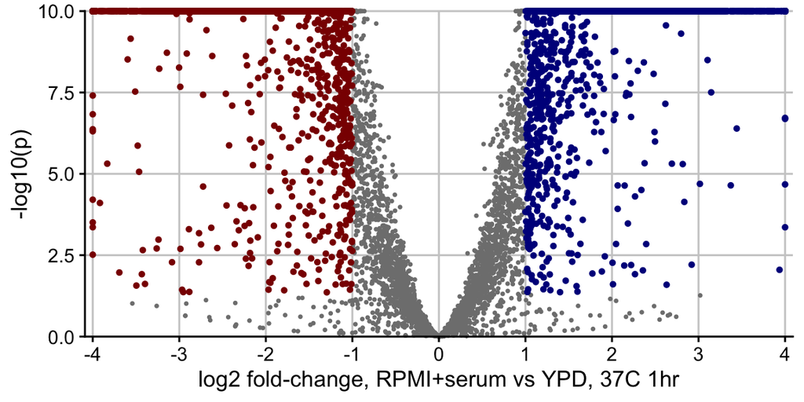

```r
volcano_WTRS2h_vs_0min <-
  ggplot(data = deseq_df_WTRS2h_vs_0min,
         aes(x = log2FC, y = -log10(padj)) ) +
  geom_point(size = 0.5, colour = "grey50") +
  geom_point(data = DEGdf_RPMI_up2x_FDR5,
             size = 1, colour = "darkblue") +
  geom_point(data = DEGdf_RPMI_down2x_FDR5,
             size = 1, colour = "darkred") +
  scale_y_continuous("-log10(p)",
                     limits = c(0,10), expand = c(0,0),
                     oob=scales::squish) +
  scale_x_continuous("log2 fold-change, RPMI+serum vs YPD, 37C 1hr",
                     breaks = -5:5,
                     limits = c(-4,4), expand = c(0.01,0.01),
                     oob = scales::squish) +
  coord_cartesian(clip = "off")
volcano_WTRS2h_vs_0min
```

## Write outputs to files

```r
deseq_df_WTRS2h_vs_0min %>%
  dplyr::mutate(
    across(c(baseMean, log2FC, stderror), round, digits = 3)
  ) %>%
  dplyr::mutate(padj = signif(padj, digits = 4)) %>%
  write_tsv(file = here::here("results",
                              "deseq_df_WT_RPMISerum120min_vs_0min.txt"))
```

## Compare differential expression in Gat201 dataset with Wakeup dataset

Note this downloads deseqdf_wakeup_file from github. You may need to change the filename if you have a local copy.

```r
deseqdf_wakeup_file <- "https://raw.githubusercontent.com/ewallace/CryptoWakeupRNASeq/main/results/DEGs/deseq_df_RPMI37C2hr_vs_0min.txt"

deseqdf_wakeup <-
  read_tsv(deseqdf_wakeup_file,
           comment = "#")
```

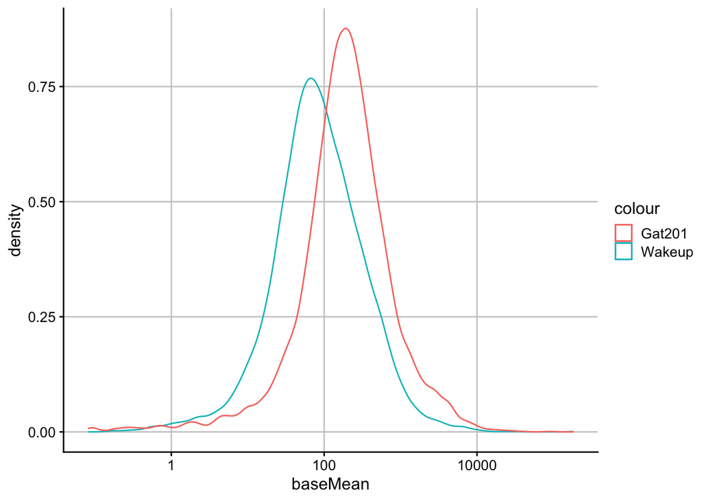

```r
deseq_joined <-
  dplyr::inner_join(
    deseqdf_wakeup,
    deseq_df_WTRS2h_vs_0min,
    by = c("gene", "geneName"),
    suffix = c("_wakeup", "_Gat201")
)

ggplot(data = deseq_joined) +
  geom_density(aes(x = baseMean_wakeup, colour = "Wakeup"))  +
  geom_density(aes(x = baseMean_Gat201, colour = "Gat201")) +
  scale_x_log10("baseMean")
```

```r
deseq_joined
```

```
## # A tibble: 6,795 × 10
##    gene       geneName baseMean_wakeup log2FC_wakeup stderror_wakeup padj_wakeup
##    <chr>      <chr>              <dbl>         <dbl>           <dbl>       <dbl>
##  1 CNAG_00002 <NA>                4.38         0.741           2.25      NA
##  2 CNAG_00003 <NA>               37.2         -1.40            1.11       0.652
##  3 CNAG_00004 <NA>              108.          -0.903           0.663      0.602
##  4 CNAG_00005 <NA>               33.2          0.738           1.11       0.879
##  5 CNAG_00006 <NA>              156.          -0.354           0.625      0.912
##  6 CNAG_00007 <NA>              107.          -0.985           0.684      0.567
##  7 CNAG_00008 <NA>              235.           0.391           0.593      0.880
##  8 CNAG_00009 <NA>               60.2          0.111           0.905      0.988
##  9 CNAG_00010 <NA>              258.           1.67            0.614      0.0789
## 10 CNAG_00011 <NA>               68.3          0.555           0.804      0.875
## # … with 6,785 more rows, and 4 more variables: baseMean_Gat201 <dbl>,
## #   log2FC_Gat201 <dbl>, stderror_Gat201 <dbl>, padj_Gat201 <dbl>
```

Correlation is overall low:

```r
deseq_joined %>%
  with(cor(log2FC_wakeup, log2FC_Gat201,
      use = "pairwise.complete.obs"))
```

```
## [1] 0.2276552
```

Correlation is still low if we filter for low-expressed genes by removing bottom 10% of baseMean:

```r
cor_log2FC_q10filtered <-
  deseq_joined %>%
  dplyr::filter(baseMean_wakeup > quantile(baseMean_wakeup, 0.1),
                baseMean_Gat201 > quantile(baseMean_wakeup, 0.1)) %>%
  with(cor(log2FC_wakeup, log2FC_Gat201,
           use = "pairwise.complete.obs"))

cor_log2FC_q10filtered
```

```
## [1] 0.2709063
```

Scatter plot for filtered data show that the dynamic range of Gat201 dataset is greater than the Wakeup dataset:

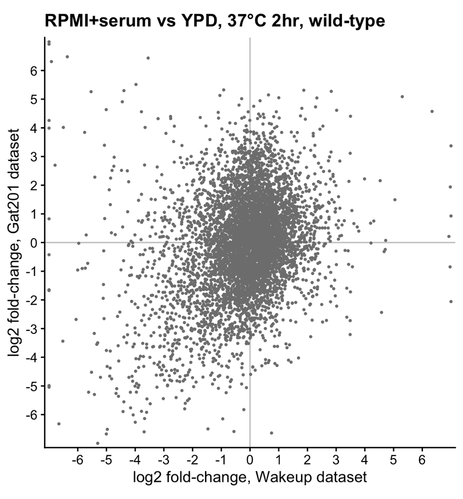

```r
plot_scatter_filtered <-
ggplot(data = deseq_joined %>%
  dplyr::filter(baseMean_wakeup > quantile(baseMean_wakeup, 0.1),
                baseMean_Gat201 > quantile(baseMean_wakeup, 0.1)),
       aes(x = log2FC_wakeup, y = log2FC_Gat201)) +
  geom_vline(xintercept = 0, size = 0.5, colour = "grey80") +
  geom_hline(yintercept = 0, size = 0.5, colour = "grey80") +
  geom_point(size = 0.5, colour = "grey50") +
  scale_x_continuous("log2 fold-change, Wakeup dataset",
                     breaks = -6:6,
                     limits = c(-7,7), expand = c(0.01,0.01),
                     oob = scales::squish) +
  scale_y_continuous("log2 fold-change, Gat201 dataset",
                     breaks = -6:6,
                     limits = c(-7,7), expand = c(0.01,0.01),
                     oob = scales::squish) +
  coord_equal(clip = "off") +
  labs(title = "RPMI+serum vs YPD, 37°C 2hr, wild-type") +
  theme(panel.grid.major = element_blank())
plot_scatter_filtered
```

Plot with select genes highlighted. This is figure S11 of manuscript.

```r
my30genes <-
  here::here("input_annotation", "CryptoWakeup_30genes.txt") %>%
  read_tsv() %>%
  dplyr::rename(gene = GeneID)
```

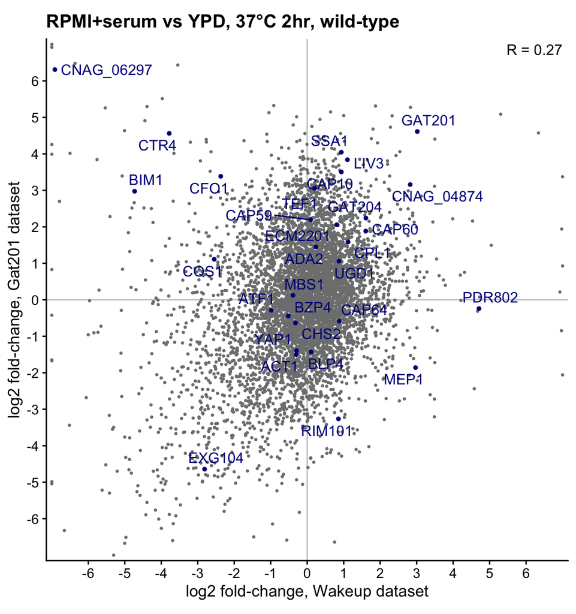

```r
deseq_joined_my30genes <-
  left_join(my30genes,
            deseq_joined %>% dplyr::select(-geneName),
            by = "gene")

plot_scatter_filtered +
  annotate("text", x = 7, y = 7, hjust = 1, vjust = 1,
           label = paste0("R = ", round(cor_log2FC_q10filtered,2))) +
  geom_point(data = deseq_joined_my30genes, size = 1, colour = "darkblue") +
  geom_text_repel(data = deseq_joined_my30genes,
                  aes(label = GeneName), colour = "darkblue")
```

```r
ggsave(here::here("results", "compare_2datasets_DESeq_WT2h_vs_0min.png"),
       height = 6.4, width = 6)
```